# # Red Wine Alaysis

# Bivariate Analysis

In the First Graph of this analysis is between the quality and alcohol in % So, this graph shows that the alcohol % in wine increases as the quality of wine increases, So, this states that the good quality wines have the higher value of alcohol % in them then the low quality fines But there is point in graph that is for quality 4 alcohol % is higher than the quality 5 wines. But there are also other factors which effect the quality of wines. When I see the graph of quality vs pH, After that I came to Know that the wines has almost same pH value there is no much difference in them. But in very next graph of alcohol and pH, So the pH value has increased with the amount of alcohol % has increased in red wine. The most amzing thing I found is that the amount of citric acid is increased the value of fixed acidity also inreased linearly with it.When I compaired all the acidities with the alcohol then I found that as the amount of all the acidities has increased the alcohol amount has decreased with the volatile acidity and it increased with the amount of citric acid but remained same with the fixed acidity. As the amount of citric acid has increased in red wine then the quality of it has increased that this means that the good quality wines have a higher quanity of citric acid present in them.

### Talk about some of the relationships you observed in this part of the . How did the feature(s) of interest vary with other features in dataset?

In this main point is quality, So, very first graph has given that the alcohol% increases with the quality of the red wine has increased it. And the good quality Red Wines have nice amount of citric acid present in them as it is added to add freshness in red wines.

### Did you observe any interesting relationships between the other features (not the main feature(s) of interest)?

The other interesting relations, Volatile acidity i.e. acetic acidity amount has decreased with the increase in the amount of citric acid in the red wine and the vloatile acidity has no major effect on the fixed acidity of red wines.

### What was the strongest relationship you found?

Quality and alcohol

# Multivariate Plots Section

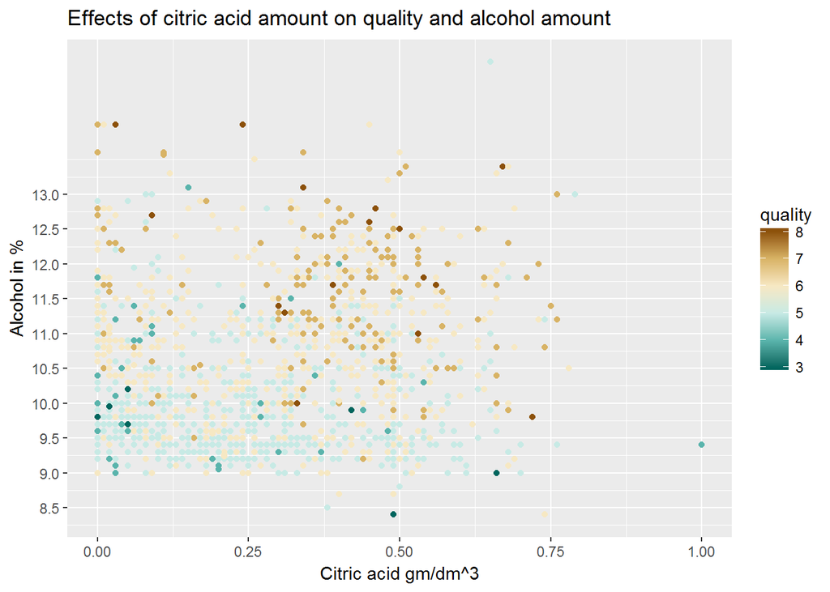

```r
# Effect of citric acid on quality and alcohol

ggplot(aes(x = citric.acid,y = alcohol,color = quality),data = wine) +
  geom_point() +
  scale_y_continuous(breaks = seq(8,13,0.5)) +
  scale_color_distiller(type = 'div') +
  xlab('Citric acid gm/dm^3') +
  ylab('Alcohol in %') +
  ggtitle('Effects of citric acid amount on quality and alcohol amount')
```

In this the higher quality wines has the either higher amount of alcohol or higher amount of citric acid present in it.

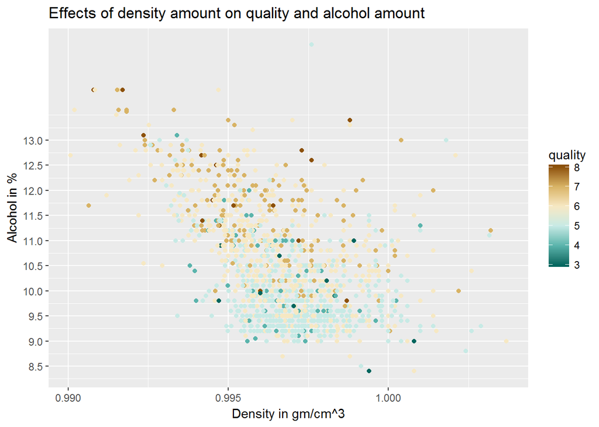

```r
#effect of density on quality and alcohol

ggplot(aes(x = density,y = alcohol,color = quality),data = wine) +
  geom_point() +
  scale_y_continuous(breaks = seq(8,13,0.5)) +
  scale_color_distiller(type = 'div') +
  xlab('Density in gm/cm^3') +
  ylab('Alcohol in %') +
  ggtitle('Effects of density amount on quality and alcohol amount')
```

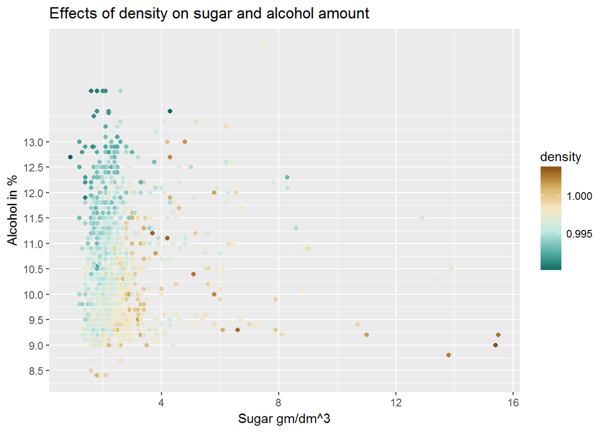

```r
#density with alcohol and sugar

ggplot(aes(x = residual.sugar,y = alcohol,color = density),data = wine) +
  geom_point() +
  scale_y_continuous(breaks = seq(8,13,0.5)) +
  scale_color_distiller(type = 'div') +
  xlab('Sugar gm/dm^3') +
  ylab('Alcohol in %') +
  ggtitle('Effects of density on sugar and alcohol amount')
```

Higher the density which means that it has the high amount of sugar and low amount of alcohol present in red wine.

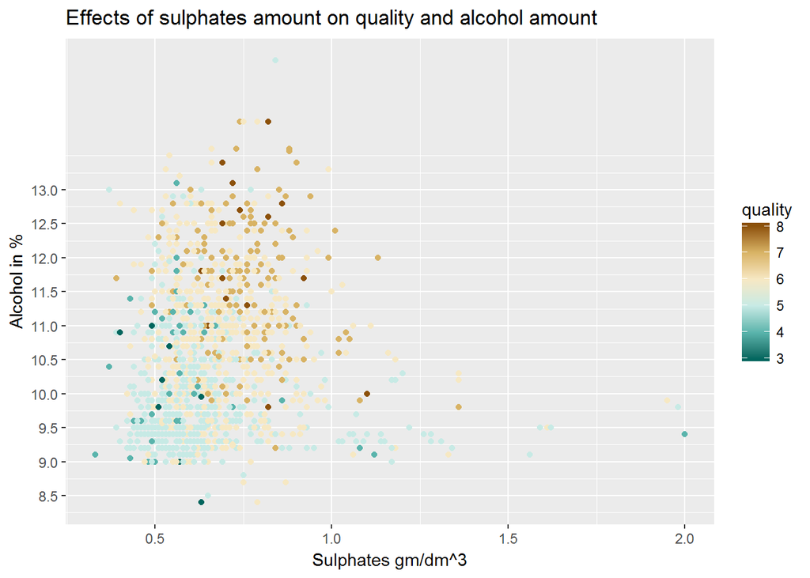

```r
#Effect of sulpahtes amount on alcohol and quality

ggplot(aes(x = sulphates,y = alcohol,color = quality),data = wine) +
  geom_point() +
  scale_y_continuous(breaks = seq(8,13,0.5)) +
  scale_color_distiller(type = 'div') +
  xlab('Sulphates gm/dm^3') +
  ylab('Alcohol in %') +
  ggtitle('Effects of sulphates amount on quality and alcohol amount')
```

All the qualities of wine has lower amount of sulphates present in them whatever the amount of alcohol is present in it.

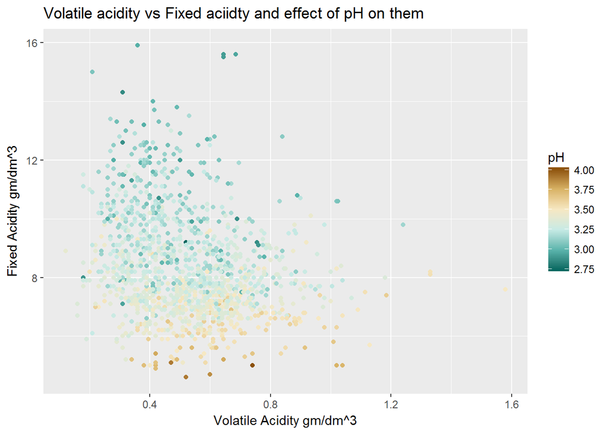

```r
#fixed acidity and volatile acidity and pH

ggplot(aes(x = volatile.acidity,y = fixed.acidity,color = pH),data = wine) +
  geom_point() +
  scale_color_distiller(type = 'div') +
  xlab('Volatile Acidity gm/dm^3') +
  ylab('Fixed Acidity gm/dm^3') +
  ggtitle('Volatile acidity vs Fixed aciidty and effect of pH on them')
```

In this graph, Red wines with higher amount of fixed acidity and lower amount of volatile acidity has low pH value which means they are more acidic.

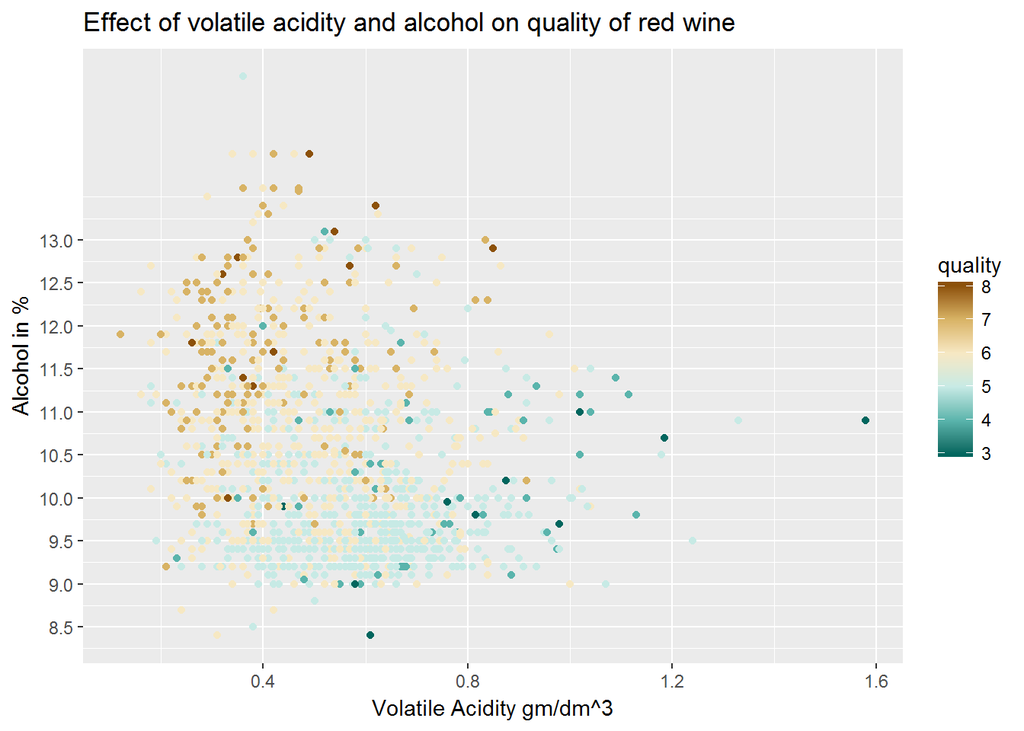

```r
# effect of volatile acidity and alcohol on quality of red wine

ggplot(aes(x = volatile.acidity,y = alcohol,color = quality),data = wine) +
  geom_point() +
  scale_y_continuous(breaks = seq(8,13,0.5)) +
  scale_color_distiller(type = 'div') +
  xlab('Volatile Acidity gm/dm^3') +
  ylab('Alcohol in %') +
  ggtitle('Effect of volatile acidity and alcohol on quality of red wine')
```

# Multivariate Analysis

### Were there any interesting or surprising interactions between features?

# Final Plots and Summary

### Plot One

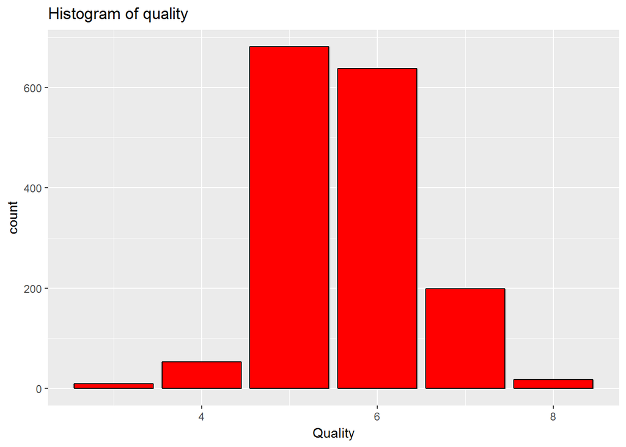

```r
# quality

ggplot(aes(x = quality),data = wine) +
  ggtitle('Histogram of quality') +
  ylab('count') +
  xlab('Quality') +
  geom_histogram(stat = 'count',color = 'black', fill = 'red')
```

### Description One

This graph is selected as it is main feature i have thought with which majorly other factors depend upon.

### Plot Two

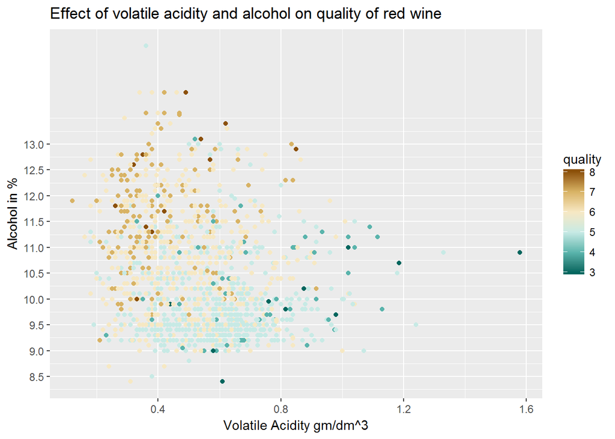

```r
# effect of volatile acidity and alcohol on quality of red wine

ggplot(aes(x = volatile.acidity,y = alcohol,color = quality),data = wine) +
  geom_point() +
  scale_y_continuous(breaks = seq(8,13,0.5)) +
  scale_color_distiller(type = 'div') +
  xlab('Volatile Acidity gm/dm^3') +
  ylab('Alcohol in %') +
  ggtitle('Effect of volatile acidity and alcohol on quality of red wine')
```

### Description Two

They are main things that effect the quality of red wines, Which means that the higher quality wines has higher amount of alcohol present in them and the low amount of acetic acid present in it.

### Plot Three

[figure not shown]

```r
#Effect of sulpahtes amount on alcohol and quality

ggplot(aes(x = sulphates,y = alcohol,color = quality),data = wine) +
  geom_point() +
  scale_y_continuous(breaks = seq(8,13,0.5)) +
  scale_color_distiller(type = 'div') +
  xlab('Sulphates gm/dm^3') +
  ylab('Alcohol in %') +
  ggtitle('Effect of volatile acidity and alcohol on quality of red wine')
```

### Description Three

# Reflection

I have selected this dataset because I want to know that what things effect the quality of red wines. Before this analysis i didn’t anything about the red wines, now, I now what factors are needed to make the good quality of wines so that it is good in taste and doesn’t cause any health problem to the body and eevryone should like it.